# Virginia Math Bulletin

### 2020 UVA REU Program

The UVa Department of Mathematics organized a summer research experience for undergraduate students in June and July 2020. The program was supported by grants from the National Science Foundation (i.e. RTG grant and another REU grant), the National Security Agency, the Templeton World Charity Foundation, as well as some private donors. The program entitled "Number Theory, Representation Theory and Topology" was headed by a management team consisting of Professors Julie Bergner, Thomas Koberda, Thomas Mark, and Ken Ono.

The diverse group of 28 participants included 13 men and 15 women from colleges and universities across the country, including the Lafayette College, University of Maryland, Wake Forest University, and Marshall University in the mid-Atlantic region as well as many further-off schools such as Harvard, Harvey Mudd, MIT, Stanford, University of Chicago, University of Michigan and the University of California.

Although the pandemic necessitated significant changes to the planned program, the participants enjoyed 6 weeks of virtual research activities. These activities included a lecture series, various mini-courses, panel discussions, and in-depth guided research with UVa faculty mentors, supported by UVa graduate students and postdocs.

The invited speakers were: Henri Darmon (McGill), Sang-hyun Kim (KIAS), James Maynard (Oxford University), Lillian Pierce (Duke), Ken Ribet (UC Berkeley), and Maryna Viazovska (École Polytechnique, Lausanne), as well as UVa mathematics faculty members Benjamin Hayes, Slava Krushkal, Nick Kuhn, Sara Maloni, and Ken Ono.

The mini-courses were:

- Essentials of topology and geometry of manifolds (Instructors: Julie Bergner, Thomas Koberda, Tom Mark)
- Beyond the Mordell-Weil Theorem (Instructor: Charlotte Ure)
- Complex multiplication: Constructing Hilbert class fields (Instructor: Jinbo Ren)
- Representation Theory and Symmetric Groups (Instructor: You Qi)
- Brauer Groups: What are they and what are they good for? (Instructor: Evangelia Gazaki)

[figure not shown]

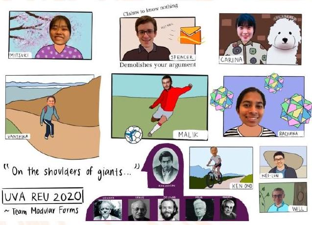

As well as receiving guidance from the lead faculty members and guest mentors Jesse Thorner (University of Illinois, Urbana-Champaign) and Wei-Lun Tsai, participants worked closely with graduate student mentors from the UVa math department: Ross Akhmechet, Will Craig, Peter Johnson, Christopher Lloyd, Eleanor McSpirit, Badri Pandey, Ian Runnels, Shunyu Wan and Jiajun Yan.

The participants completed 8 papers that have been submitted for publication in peer reviewed mathematics journals. These papers are:

- M. Amir and L. Hong, On $L$-functions of modular elliptic curves and certain K3 surfaces, Ramanujan Journal, accepted for publication.
- T. Blum, C. Choi, A. Hoey, J. Iskander, K. Lakein, and T. Martinez, On class numbers, torsion subgroups, and quadratic twists of elliptic curves, submitted for publication.
- S. Dembner and V. Jain, Hyperelliptic curves and newform coefficients, submitted for publication.
- S. Dembner and V. Jain, A note on congruences for weakly holomorphic modular forms, submitted for publication.
- M. Hanada and R. Madhukara, Fourier coefficients of level 1 Hecke eigenforms, submitted for publication.
- L. Hong and S. Zhang, Towards Heim and Neuhauser’s unimodality conjecture on the Nekrasov-Okounkov polynomials, Research in Number Theory, accepted for publication.
- T. Khale, C. O’Kuhn, A. Panidapu, A. Sun, and S. Zhang, A Bombieri-Vinogradov Theorem for primes in short intervals and small sectors, submitted for publication.
- A. Panidapu and J. Thorner, The CM Sato-Tate distribution in short intervals, submitted for publication.

Number theory participant Vanshika Jain has been awarded Honorable Mention for the 2021 Alice T. Schafer Prize by the Association for Women in Mathematics. The Schafer Prize recognizes the best undergraduate women in mathematics.

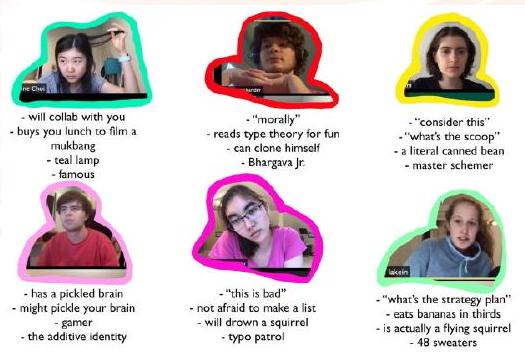

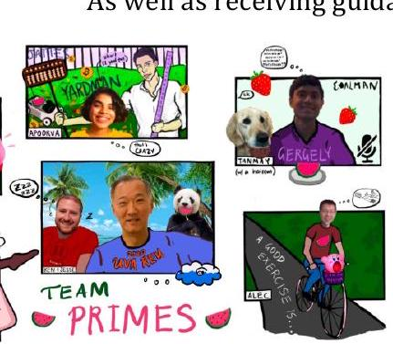

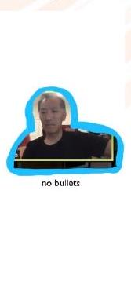

## Recent PhDs

### Thomas Sale

*Advisor: Weiqiang Wang*  
**Quantum Symmetric Pairs and Quantum Supergroups at Roots of 1**

A quantum group, as conceived by Drinfeld and Jimbo, is the quantization of an enveloping algebra via the quantum parameter $v$. In analogue with the theory of algebraic groups in prime characteristic, Lusztig laid the foundations of a theory of quantum groups when $v$ has been specialized to a root of 1. Among his fundamental results and constructions are a quantum Frobenius homomorphism, a Steinberg tensor product theorem and the small quantum group.

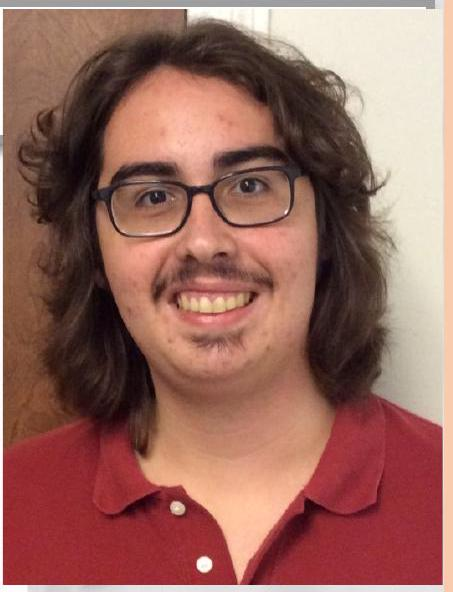

In this dissertation, we extend the aforementioned results to two related settings. A quantum symmetric pair is the quantization of a symmetric pair of a Lie algebra and its fixed point subalgebra under an involution; the corresponding subalgebra is called an $\imath$ quantum group. In the first part of the dissertation, we show that Lusztig’s Frobenius homomorphism restricts to a map of $\imath$ quantum groups in finite type. We also formulate the small $\imath$ quantum group and compute its dimension. A number of elements are shown to be central in the $\imath$ quantum group at a root of 1. In $ADE$ type, the action of the $\imath$ quantum group at a root of 1 on the quantized adjoint module gives rise to a Lie algebra isomorphic to the symmetric pair subalgebra.

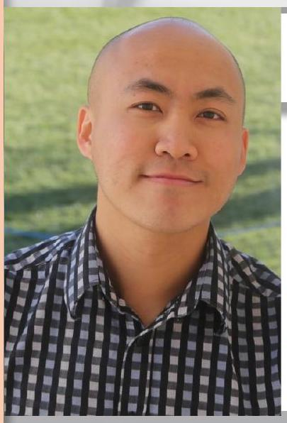

### Huy Dang

*Advisor: Andrew Obus*  
**Hurwitz Trees and Deformations of Cyclic Covers**

The main focus of this thesis is equal characteristics deformations of Artin-Schreier covers (of curves). We formulate some conditions on a combinatorial object called Hurwitz tree to determine the existence of certain types of deformations of given degree $p$ cyclic branched covers. Furthermore, by applying these Hurwitz tree criteria, we show that the moduli space of Artin-Schreier curves of fixed genus $g$ is connected when $g$ is sufficiently large.

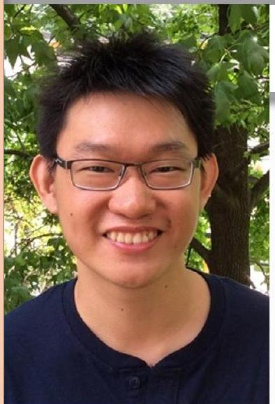

### Christopher Chung

*Advisor: Weiqiang Wang*  
**Quantum Covering Groups and Quantum Symmetric Pairs**

A quantum covering group $\mathbf{U}_{\pi}$ is an algebra with parameters $q$ and $\pi$ subject to $\pi^{2}=1$ and it admits an integral form; it specializes to the usual quantum group at $\pi=1$ and to a quantum supergroup of anisotropic type at $\pi=-1$. In this dissertation, we establish the Frobenius-Lusztig homomorphism and Lusztig-Steinberg tensor product theorem in the setting of quantum covering groups at roots of 1, recovering Lusztig’s constructions for quantum groups at roots of 1 when we specialize at $\pi=1$.

We develop a theory of quantum symmetric pair $\left(\mathbf{U}_{\pi}, \mathbf{U}_{\pi}^{\imath}\right)$, where $\mathbf{U}_{\pi}^{\imath}$ is a coideal subalgebra of $\mathbf{U}_{\pi}$. When specializing at $\pi=1$, the pair $\left(\mathbf{U}_{\pi}, \mathbf{U}_{\pi}^{\imath}\right)$ reduces to a quantum symmetric pair of G. Letzter and its Kac-Moody generalization by Kolb. We give a Serre presentation for $\mathbf{U}_{\pi}^{\imath}$ of quantum symmetric pairs $\left(\mathbf{U}_{\pi}, \mathbf{U}_{\pi}^{\imath}\right)$ for quantum covering groups, introducing the $\imath^{\pi}$-Serre relations and $\imath^{\pi}$-divided powers. We also develop a quasi $K$-matrix in this setting, which leads to a construction of $\imath$-canonical bases for the highest weight integrable $\mathbf{U}_{\pi}$-modules and their tensor products regarded as $\mathbf{U}_{\pi}^{\imath}$-modules, as well as an $\imath$-canonical basis for the modified form of the $\imath$ quantum group $\mathbf{U}_{\pi}^{\imath}$. Again, specializing at $\pi=1$ we recover the Serre presentation of $\mathbf{U}^{\imath}$ by Chen-Lu-Wang and the canonical basis construction of Bao-Wang. The specialization at $\pi=-1$ leads to new constructions for quantum supergroups.

### Andrew Kobin

*Advisor: Andrew Obus*  
**Wild Ramification and Stacky Curves**

The local structure of Deligne-Mumford stacks has been studied for decades, but most results require a tameness hypothesis that avoids certain phenomena in positive characteristic. We tackle this problem directly and classify stacky curves in characteristic $p>0$ with cyclic stabilizers of order $p$ using higher ramification data. Our approach replaces the local root stack structure of a tame stacky curve, similar to the local structure of a complex orbifold curve, with a more sensitive structure called an Artin-Schreier root stack, allowing us to incorporate the ramification data directly into the stack. A complete classification of the local structure of stacky curves, and more generally Deligne-Mumford stacks, will require a broader understanding of root structures, and we begin this program by introducing a higher-order version of the Artin-Schreier root stack. Finally, as an application, we compute dimensions of Riemann-Roch spaces for some examples of stacky curves in positive characteristic and suggest a program for computing spaces of modular forms using the theory of stacky modular curves.

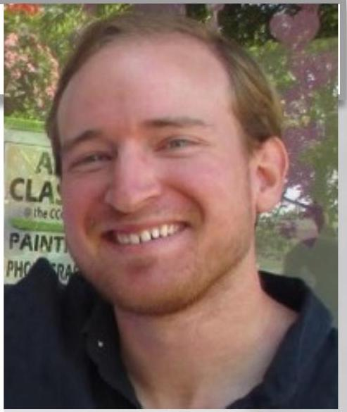

### Bogdan Krstic

*Advisor: Nicholas Kuhn*  
**Bispans in Quasicategories**

A Tambara functor is an algebraic system indexed by the subgroups of a fixed finite group, possessing additive and multiplicative inductions along subgroup inclusions as well as a twisted distributive law between the two inductions. These arise in equivariant homotopy theory and group representation theory, with examples coming from representation rings, generalized character rings, equivariant $K$-theory, Burnside rings, group cohomology, algebraic $K$-theory, and homotopy groups of equivariant $E_{\infty}$-ring spectra. Tambara functors are defined using bispan categories, which simultaneously encode the inductive system and distributive law. Many Tambara functors can be defined in a compatible manner for all groups at once, suggesting the notion of a global Tambara functor. Encoding the distributivity properties for global equivariant phenomena suggests passage to bispans in the bicategory of finite groupoids, but the complicated nature of bispan composition means that an axiomatic elaboration of global Tambara functors has yet to be provided, although work of Schwede suggests a relationship to global Mackey functors with power operations. In this thesis, we provide a quasicategorical bispan construction, initiating the development of the higher categorical framework needed to study global Tambara functors.

We provide a construction of a quasicategory of bispans in a locally cartesian closed quasicategory which is compatible with the span quasicategory of Barwick. In particular, we obtain a quasicategory whose simplices consist of diagrams encoding higher composites of bispans. To this end, we develop and study quasicategorical analogues of exponential diagrams, which are the categorical construction governing composition in bispan categories.

We first generalize a theory of bispans in the category of finite sets appearing in the thesis of Cranch, creating a "decomposed" bispan quasicategory. The decomposed bispan diagrams of Cranch are sub-simplicial sets of the bispan diagrams used for the main construction, and we establish pleasant properties of these inclusions. With these results in hand, we prove that what is a priori a simplicial set of bispans is in fact trivially fibered over the decomposed bispan quasicategory, thus obtaining the desired quasicategory of bispans.

### Mark Lewers

*Advisor: Yen Do*  
**Carleson Embeddings into Weighted Outer Measure Spaces**

Recent progress in harmonic analysis in obtaining $L^{p}$ norm inequalities for modulation invariant operators has been in part due to the formalization of time-frequency analysis methods under an outer measure framework developed in [DT15]. The framework codifies the underlying nature of such an analysis and shifts the difficulty in proofs to obtaining $L^{p}$ norm estimates on projection operators mapping from a classic $L^{p}$ space into an outer measure $L^{p}$ space; such maps are referred to as (generalized) Carleson embeddings. This dissertation seeks to extend known generalized Carleson embeddings in outer $L^{p}$ theory from non-weighted settings to weighted settings. The highlight estimate of this work is a generalized Carleson embedding for the wave packet transform
$$f \mapsto \mathbb{F}_{\phi}(f)(y, \eta, t):=\int_{\mathbb{R}} f(x) \frac{1}{t} e^{i \eta(y-x)} \phi\left(\frac{y-x}{t}\right) \mathrm{d} x, \quad(y, \eta, t) \in \mathbb{R} \times \mathbb{R} \times(0, \infty)$$
of a function $f \in L^{p}(\mathbb{R}, w)$ into a weighted outer $L^{p}$ space situated in $\mathbb{R} \times \mathbb{R} \times(0, \infty)$ for exponents $p>2$ and Muckenhoupt weights $w \in \mathbb{A}_{p / 2}$. The wave packet transform is a projection of modulation invariant operators into $\mathbb{R} \times \mathbb{R} \times(0, \infty)$ as mentioned in [DT15, DPO18, Ura16] and generalized Carleson embeddings of this transform are known in non-weighted settings. The proof utilizes weighted phase plane techniques adapted to a continuum along with new restriction $L^{2}$ estimates for the wave packet transform.

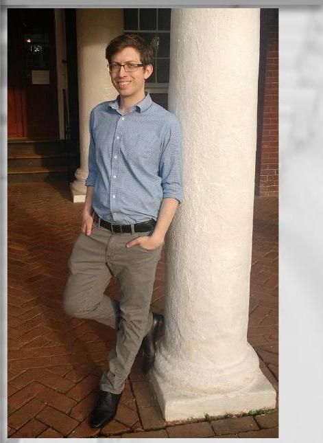

### Mark Schrecengost

*Advisor: Peter Abramenko*  
**Finite Generation of RGD Systems with Exceptional Links**

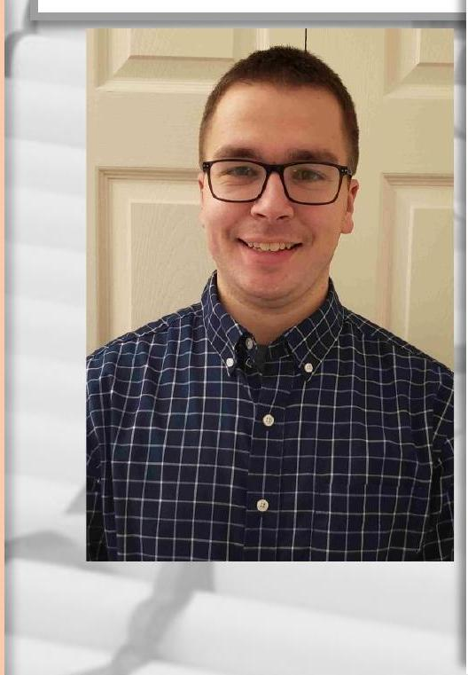

Let $\left(G,\left(U_{\alpha}\right)_{\alpha \in \Phi}, T\right)$ be an RGD system. The most prominent examples are Kac-Moody groups, which are infinite dimensional analogs of semisimple Lie groups. These groups have an associated twin building $\Delta$ on which the group $G$ will act strongly transitively. We say that the building $\Delta$ satisfies condition (co) if the collection of chambers opposite any chamber is gallery connected. It is known that if $\Delta$ satisfies (co), the subgroup $U_{+}$ of $G$ is generated by some finite set of fundamental root groups, and thus is finitely generated if these root groups are finitely generated.  
We will help close the gap in the literature relying on condition (co) by proving when the subgroup $U_{+}$ of an RGD system associated to rank-3 buildings is finitely generated. Most of the time, the group $U_{+}$ will not be finitely generated, and we will give sufficient conditions to guarantee the infinite generation of $U_{+}$. We will then modify this approach to see that another group not covered by the conditions is also not finitely generated. Our main strategy will be to produce a large family of surjective homomorphisms from $U_{+}$ which send relatively few $U_{\alpha}$ to non-identity elements, implying that some of these $U_{\alpha}$ must be in any generating set.  
Finally, we will show that there are two cases where $U_{+}$ remains finitely generated despite $\Delta$ not satisfying (co). We will use an approach which relies on defining a distance between root groups, and showing that most root groups can be expressed in terms of those closer to the fundamental chamber. This approach can also give another proof of the finite generation of $U_{+}$ with condition (co).

### 2019-2020 Outstanding Mathematics Graduate Teaching Assistant Award: Andrew Kobin

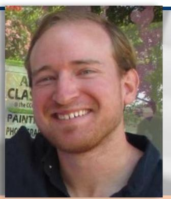

### 2019-2020 All-University Graduate Teaching Award: Sarasij Maitra

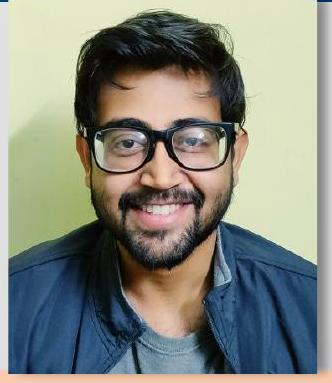

## Online Life at the Math Department

University of Virginia transitioned to remote teaching in March 2020, and our Department is staying mostly online for the 2020-21 academic year.

The end of the Spring semester was unusual and dramatic. It felt like in-person social interactions in the Department stopped. We started weekly online "tea time" Zoom meetings at the usual department tea times on Thursdays at 3:15, to preserve communication at least in some form. This has become our new social tradition in the online world.

In May, we gathered students and their families across the nation and the world for the 2020 online installment of the Department of Mathematics Diploma Ceremony (shown in the picture).

The research part of our activities changed, too. Now anyone can attend any mathematical seminar or conference happening around the world and listen to the live or recorded broadcast of fresh mathematical ideas. However, it turned out that the online format cannot imitate another very important part of mathematical seminars and conferences - the cherished "coffee breaks" between talks, packed with exchange of ideas and sparks of new collaborations with colleagues. When it becomes possible to travel again, this aspect of mathematical research will be the main reason to resume in-person conferences and seminars.

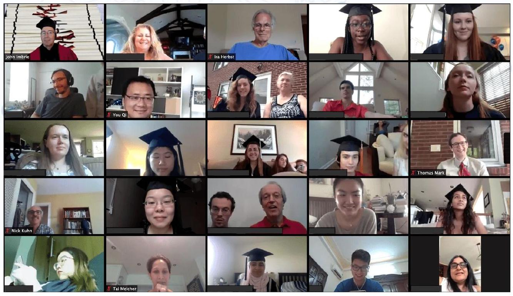

Over the summer of 2020, the University took efforts to prepare for the upcoming online semester. I served as an "Instructional Partner" - a point of contact for my colleagues who worked hard to redesign their courses for the online teaching environment. Everyone had to recreate lectures, blackboard and chalk, quizzes, group discussions, homework, exams, and other components of effective teaching in a fully digital form. These changes inevitably lead to implementing some teaching innovations which benefited student learning. For example, some of us "inverted" our classrooms: The instructor pre-records the lectures, students view them as a part of the homework, while the class meeting times are dedicated to discussing problems and examples.

### What Are You Doing? We’d Love to Hear from You!

Email: math-newsletter@virginia.edu Department of Mathematics  
News & Events: http://math.virginia.edu/allnews/ University of Virginia  
P. O. Box 400137  
Charlottesville, VA 22904-4137